# DSA GROUP PROJECT

FIFA WORLD CUP 72759

`16-11-2023`

## Introduction

The FIFA World Cup, being one of the most anticipated global competitions, has been held every four years since 1930. Hence, our team is interested in investigating the countries who have a relatively higher participation rate that have shown the most improvement in the World Cup based on three aspects: the **number of effective goals** (goals scored minus goals conceded), **win rate** and **Elo rating**.

## Data Cleaning

First, we identified the **top 8** countries with the highest participation number. These countries consist of **Brazil, Germany, Italy, Argentina, Mexico, England, France and Spain**. We have represented this information in a bar chart, organized in ascending order to illustrate the frequency of their participation.

Excluding countries with low participation rates ensures a more reliable analysis by focusing on countries with a consistent showup in the FIFA World Cup. This methodology strengthens the validity and generalizability of the findings, providing a more accurate assessment of goal-scoring trends.

```r
#Load library
library(stringr)
library(readr)
library(tidyverse)

#Read data
wcmatches <- read_csv('https://raw.githubusercontent.com/rfordatascience/tidytuesday/master/data/2022/2022-11-29/wcmatches.csv')
worldcups <- read_csv('https://raw.githubusercontent.com/rfordatascience/tidytuesday/master/data/2022/2022-11-29/worldcups.csv')

#combine West Germany into Germany
wcmatches = wcmatches%>%
  mutate(home_team = ifelse(home_team == "West Germany", "Germany", home_team),
         away_team = ifelse(away_team == "West Germany", "Germany", away_team)) %>%
  select(-(city:stage), -win_conditions, -(date:dayofweek))

participants <- wcmatches %>%
  select(year, home_team, away_team) %>%
  pivot_longer(cols = home_team:away_team, names_to = "team", values_to = "country") %>%
  select(-team) %>%
  distinct(year, country) %>%
  count(country) %>%
  arrange(desc(n))

top_8_participants <- participants %>%
  pull(country)

top_8_participants = top_8_participants[1:8]
```

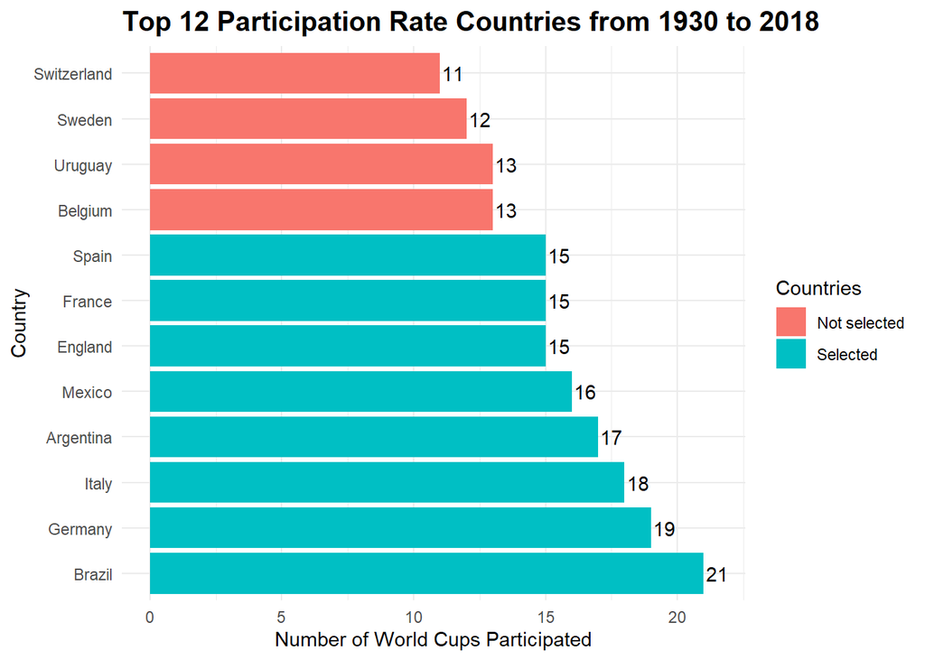

```r
top_12_participants <- participants %>%
  top_n(12) %>%
  mutate(country = factor(country, levels = participants$country))%>%
  mutate(selected = ifelse(country %in% top_8_participants, "Selected","Not selected"))

participants_plot <- ggplot(top_12_participants, aes(x = country, y = n)) +
  geom_col(aes(fill = selected)) +
  coord_flip() +
  geom_text(aes(y = n + 0.5, label = n)) +
  labs(x = "Country", y = "Number of World Cups Participated",
       title = "Top 12 Participation Rate Countries from 1930 to 2018", fill = "Countries") +
  theme_minimal() +
  theme(plot.title = element_text(face = 2, size = 15))

participants_plot
```

## Data Visualization

### Effective Goals

We calculated the number of effective goals, referred to as the `gap`, for each country by subtracting the goals scored (`score`) with the goals conceded (`opp_score`). We computed the annual average gap (`avg_gap`) for each country and calculated the slope of the linear regression line to analyze the trend of each country’s goal difference over the years. Steeper positive slopes indicate a more significant positive trend in goal-scoring performance.

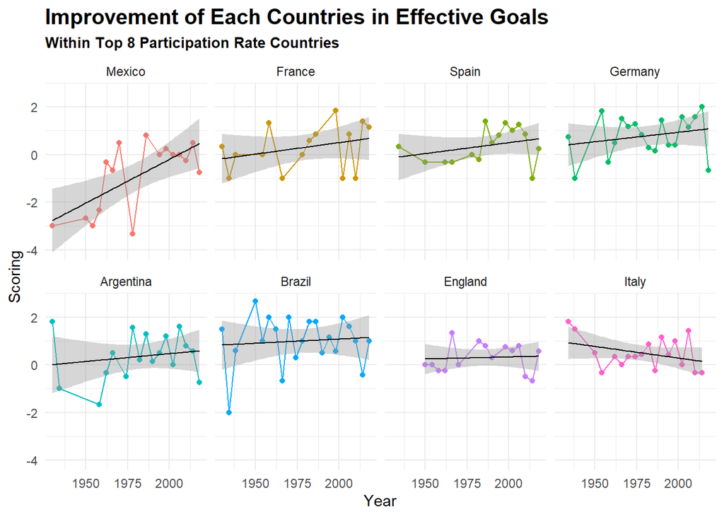

```r
home_goals = wcmatches %>%
  select(year, home_team, home_score) %>%
  rename(team = home_team,
         score = home_score)

away_goals = wcmatches %>%
  select(year, away_team, away_score) %>%
  rename(team = away_team,
         score = away_score)

home_opp_goals = wcmatches %>%
  select(year, home_team, away_score) %>%
  rename(team_a = home_team,
         opp_score = away_score,
         year_a = year)

away_opp_goals = wcmatches %>%
  select(year, away_team, home_score) %>%
  rename(team_a = away_team,
         opp_score = home_score,
         year_a = year)

goals = rbind(home_goals,away_goals)
opp_goals = rbind(home_opp_goals,away_opp_goals)


goal <- cbind(goals, opp_goals) %>%
  select(year, team, score, opp_score) %>%
  mutate(gap = score - opp_score) %>%
  group_by(year, team) %>%
  summarize(avg_gap = mean(gap), .groups = "drop") %>%
  filter(team %in% top_8_participants)

avg_gap_slope <- goal %>%
  group_by(team) %>%
  summarize(slope = summary(lm(avg_gap ~ year))$coefficients[2], .groups = "drop") %>%
  arrange(desc(slope)) %>%
  pull(team)

goal <- goal %>%
  mutate(team = factor(team, levels = avg_gap_slope))

goal_plot <- ggplot(goal, aes(x = year, y = avg_gap)) +
  geom_line(aes(color = team)) +
  geom_point(aes(color = team)) +
  geom_smooth(method = "lm", color = "black", formula = y ~ poly(x, 1), linewidth = 0.5) +
  facet_wrap(~ team, nrow = 2, ncol = 4) +
  labs(title = "Improvement of Each Countries in Effective Goals",
       subtitle = "Within Top 8 Participation Rate Countries",
       x = "Year", y = "Scoring") +
  theme_minimal() +
  theme(legend.position = "none", plot.title = element_text(face = 2, size = 15), plot.subtitle = element_text(face = 2, size = 10))

goal_plot
```

### Win Rate

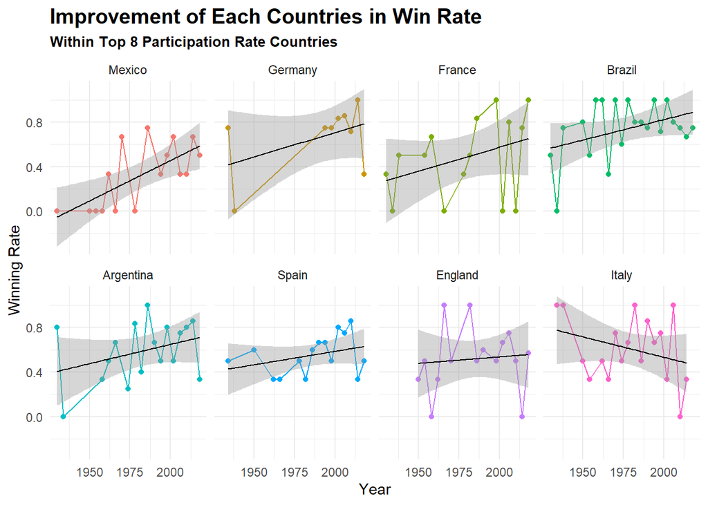

```r
win <- wcmatches %>%
  select(year, winning_team) %>%
  na.omit() %>%
  group_by(year) %>%
  count(winning_team) %>%
  rename(team = winning_team, win_match = n)

lose <- wcmatches %>%
  select(year, losing_team) %>%
  na.omit() %>%
  group_by(year) %>%
  count(losing_team) %>%
  rename(team = losing_team, lose_match = n)

win_rate <- win %>%
  full_join(lose, by = c("year", "team")) %>%
  mutate_all(replace_na, 0) %>%
  group_by(year, team) %>%
  summarize(rate = win_match / (win_match + lose_match)) %>%
  ungroup() %>%
  filter(team %in% top_8_participants)

win_slope <- win_rate %>%
  group_by(team) %>%
  summarize(slope = summary(lm(rate ~ year))$coefficients[2], .groups = "drop") %>%
  arrange(desc(slope)) %>%
  pull(team)

win_rate <- win_rate %>%
  mutate(team = factor(team, levels = win_slope))

matches_win_plot <- ggplot(win_rate, aes(x = year, y = rate)) +
  geom_line(aes(color = team)) +
  geom_point(aes(color = team)) +
  facet_wrap(~ team, nrow = 2, ncol = 4) +
  geom_smooth(method = "lm", color = "black", formula = y ~ poly(x, 1), linewidth = 0.5) +
  labs(title = "Improvement of Each Countries in Win Rate",
       subtitle = "Within Top 8 Participation Rate Countries",
       x = "Year", y = "Winning Rate") +
  theme_minimal() +
  theme(legend.position = "none", plot.title = element_text(face = 2, size = 15), plot.subtitle = element_text(face = 2, size = 10))

matches_win_plot
```

Based on the plot, there are noticeable fluctuations in win rates for each country. However, a positive trend unfolds from 1930 to 2018, revealing an upward trend of the linear regression line. Mexico shows the highest improvement in win rate over the period characterized by the steepest incline in the plotted graph. Following Mexico, Germany and France also showcased notable improvements in the win rate. In contrast, Italy’s performance is characterized by a negative trend, indicating a decline in effectiveness in winning games in the FIFA World Cup over the analyzed period.

### Elo Rating

Last but not least, we considered the Elo rating system as a key indicator of measurement. This system is a well-designed statistical method to quantify the relative skill levels of the teams. The Elo rating system’s primary strength lies in its consideration of opponent strength, providing a nuanced evaluation of performance. This distinctive feature is especially advantageous when teams encounter highly challenging opponents, preventing significant decline for teams that face stronger rivals.

First, we prepared a list of distinct countries involved in world cup matches. Next, we converted the `outcome` of the matches to numerical values (1 denoting win, 0.5 for a draw, 0 signifying loss). A structured data frame was then established to archive Elo ratings corresponding to each team across successive years. Notably, an initial rating of 1500 was assigned to each country making its first appearance in the competition, establishing a baseline for subsequent assessments.

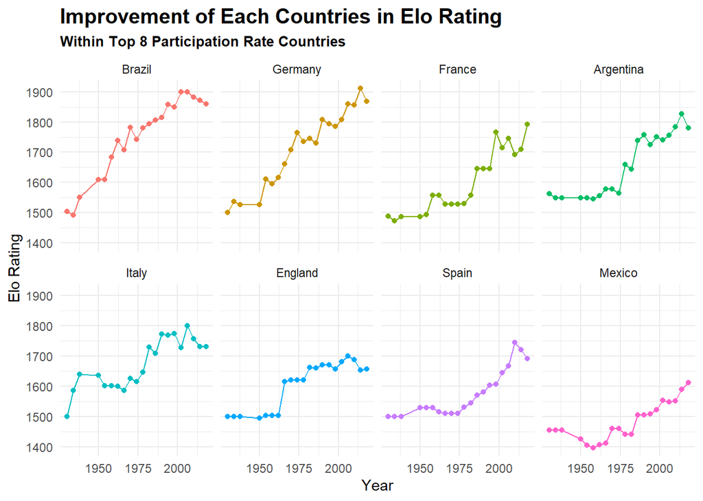

```r
# Create a list for all distinct countries
countries <- union(wcmatches$home_team, wcmatches$away_team)

# Change outcome to 1 for win, 0.5 for draw, 0 for lose
matches_result = wcmatches %>%
  mutate(outcome = ifelse(outcome == "H", 1, ifelse(outcome == "A", 0, 0.5)))

# Initialize ratings for each player
elo_ratings = data.frame(team = NA, year = NA, rating = NA)

# Initialize rating = 1500 for every country
current_elo_rating = data.frame(team = countries,
                               rating = 1500)

# Calculate Elo Rating change
calculate_elo_change = function(score, expected, k = 32) { # score = 1 for win, , 0 for lose, expected = probability to win
  round(k * (score - expected)) # k is the maximum possible adjustment per game
}

for (yr in unique(worldcups$year)) { # process year by year
  yearly_data = subset(matches_result, year == yr) # select result for that year

  for (i in 1:nrow(yearly_data)) { # for every match in that year
    home_team = yearly_data$home_team[i]
    away_team = yearly_data$away_team[i]

    home_rating = current_elo_rating[current_elo_rating$team == home_team, "rating"]
    away_rating = current_elo_rating[current_elo_rating$team == away_team, "rating"]

    home_expected_score = 1 / (1 + 10^((away_rating - home_rating + 100) / 400))
    away_expected_score = 1 / (1 + 10^((home_rating - away_rating) / 400))

    home_change = calculate_elo_change(yearly_data$outcome[i], home_expected_score)
    away_change = calculate_elo_change(1 - yearly_data$outcome[i], away_expected_score)

    current_elo_rating[current_elo_rating$team == home_team, "rating"] = home_rating + home_change
    current_elo_rating[current_elo_rating$team == away_team, "rating"] = away_rating + away_change
  }

  current_elo_rating$year = yr
  elo_ratings = rbind(elo_ratings, current_elo_rating)
}

elo_rating = elo_ratings %>%
  filter(team %in% top_8_participants)

elo_rating_slope = elo_rating %>%
  group_by(team) %>%
  summarize(slope = summary(lm(rating ~ year))$coefficients[2], .groups = "drop") %>%
  arrange(desc(slope)) %>%
  pull(team)

elo_rating <- elo_rating %>%
  mutate(team = factor(team, levels = elo_rating_slope))

elo_rating_plot <- ggplot(elo_rating, aes(x = year, y = rating, color = team)) +
  geom_line() +
  geom_point() +
  facet_wrap(~ team, nrow = 2, ncol = 4) +
    labs(title = "Improvement of Each Countries in Elo Rating",
         subtitle = "Within Top 8 Participation Rate Countries",
         x = "Year", y = "Elo Rating") +
  theme_minimal() +
  theme(legend.position = "none", plot.title = element_text(face = 2, size = 15), plot.subtitle = element_text(face = 2, size = 10))

elo_rating_plot
```

## Discussion

Analyzing the three graphs, it becomes evident that Mexico stands out in higher goal-scoring and win rate, yet it ranks last in Elo ratings. One potential reason lies in Mexico’s inconsistent performance. The Elo system may not adequately adjust the team’s rating if the team’s performance lacks consistency. Furthermore, another contributing factor is that Mexico tends to win consistently against opponents with lower Elo ratings, which does not result in substantial Elo gains. Next, we noticed that Germany and France happen to be included in the top 4 of each plot (ranks of Germany are 4th, 2nd, 2nd, and ranks of France are 2nd, 3rd, 3rd, respectively). Although Germany ranks behind France in effective goals, it has a greater improvement in other sections. Hence, we conclude that **Germany is the most improved country** among these 8 selected countries.

It is important to acknowledge the limitation of having a small sample size in our project. Our question mainly focuses on the top 8 countries in participant rate. However, leading in participant rate does not necessarily correlate with a significant improvement rate. Besides, we combined the data of West Germany and Germany while excluding the presence of East Germany, further constraining our sample size. Hence, our plots could only represent and compare improvements among these 8 countries, resulting in a potential bias limiting the generalizability of findings in determining the most improved country among all FIFA World Cup participants. These limitations are noteworthy as we acknowledge significant differences in the number of World Cup participants for each country. Discussing improvement for countries with low participation rates may lack meaningful significance. Moreover, the considerable variances in top performers for each aspect (win rate, goal-scoring, and Elo rating) makes the comparisons more challenging. As a result our project focuses on the selected 8 countries in various aspects, acknowledging the difficulty in drawing broader conclusions due to these limitations.

## References

### Data Source:

https://github.com/rfordatascience/tidytuesday/tree/master/data/2022/2022-11-29

### Other Resources:

Elo, A. E. (1978). The rating of chessplayers, past and present. Arco Pub.

Hvattum, L. M., and Arntzen, H. (2010). Using ELO ratings for match result prediction in association football. International Journal of Forecasting, 26(3), 460–470. https://doi.org/10.1016/j.ijforecast.2009.10.002

Wolf, S., Schmitt, M., and Schuller, B. (2021). A football player rating system. Journal of Sports Analytics, 6(4), 243–257. https://doi.org/10.3233/JSA-200411